# trabalho2

Agariel

2022-08-01

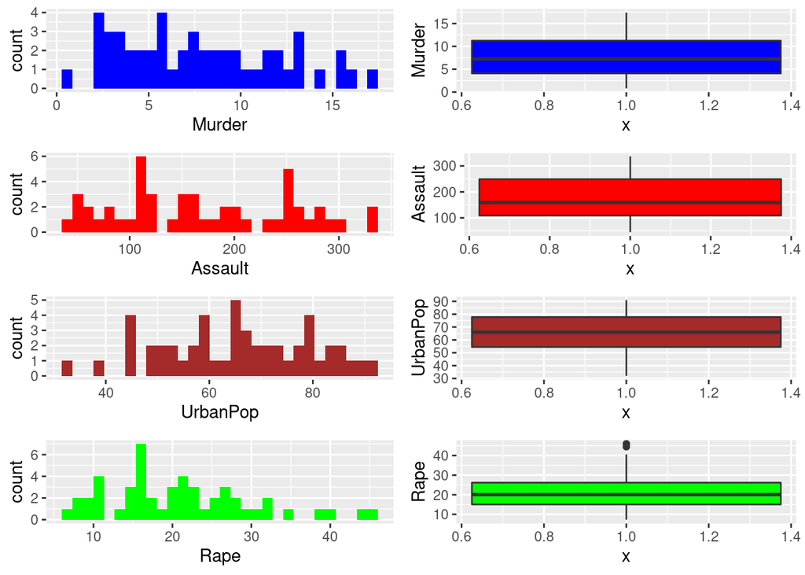

```r
#Exercicio1
#install.package{"ggplot2"}
library(ggplot2)
library(gridExtra)
#carregar conjunto de dados USArrests
data(USArrests)
mydata = USArrests

g1<- ggplot(mydata)
g1<- g1+ geom_histogram(aes(x=Murder),fill="blue")

g2<- ggplot(mydata)
g2<- g2+ geom_histogram(aes(x=Assault),fill="red")

g3<- ggplot(mydata)
g3<- g3+ geom_histogram(aes(x=UrbanPop),fill="brown")

g4<- ggplot(mydata)
g4<- g4+ geom_histogram(aes(x=Rape),fill="green")

p1<-ggplot(mydata)
p1<-p1+geom_boxplot(aes(x=1,y=Murder), fill="blue")

p2<-ggplot(mydata)
p2<-p2+geom_boxplot(aes(x=1,y=Assault),fill="red")

p3<-ggplot(mydata)
p3<-p3+geom_boxplot(aes(x=1,y=UrbanPop),fill="brown")

p4<-ggplot(mydata)
p4<-p4+geom_boxplot(aes(x=1,y=Rape),fill="green")

grid.arrange(g1, p1, g2, p2, g3, p3, g4, p4, ncol=2)
```

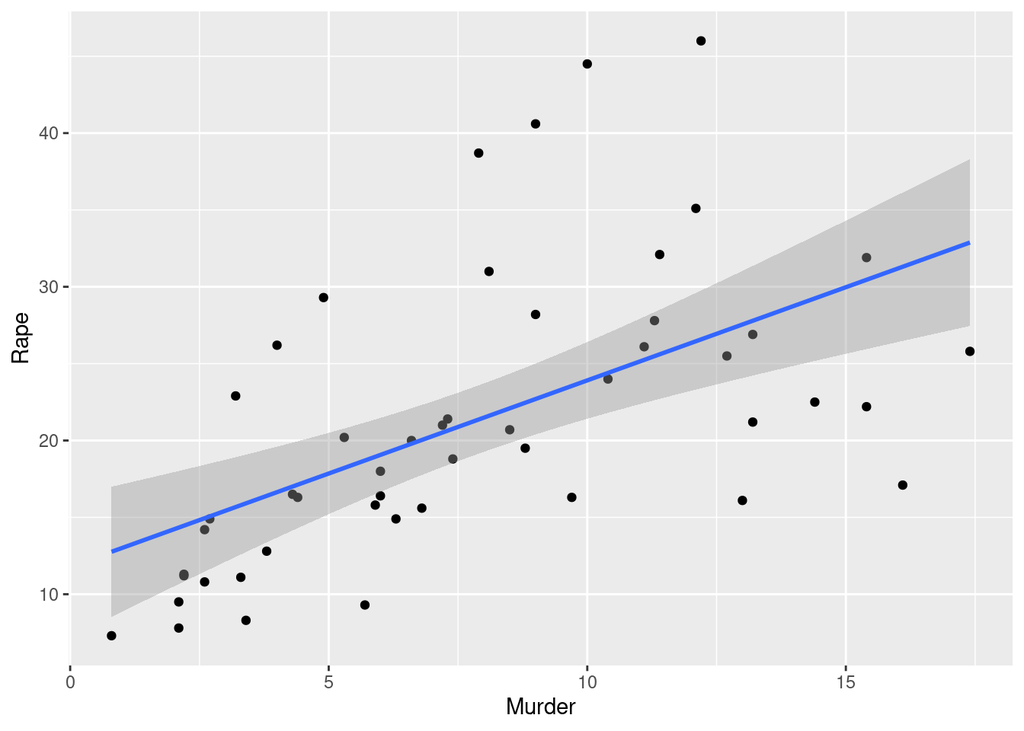

```r
#Exercício2
g5<-ggplot(mydata,aes(x=Murder,y=Rape))
g5<-g5+ geom_point()
g5<-g5+ geom_smooth(method="lm")
g5
```

Com o gráfico considerado, o objetivo é apreender se há uma relação forte entre os crimes de estupro e outros crimes de alta gravidade, como assassinatos. A relação não aparenta ser óbvia, visto que crimes como assassinato estão atrelados a tráfico de drogas, organizações criminosas, ao passo que estupro pode estar relacionado a outros fatores, como violência doméstica e cultura social. De posse do gráfico, é possível perceber que há uma correlação evidente, que é mais íntima em casos de reduzida e média criminalidade em geral, mas que se torna mais disperso à medida em que a criminalidade aumenta. É possível considerar que há uma relação existente entre os dois fenômenos, mas há outros fatores a serem levados em conta para uma compreensão mais profunda do fenômeno.

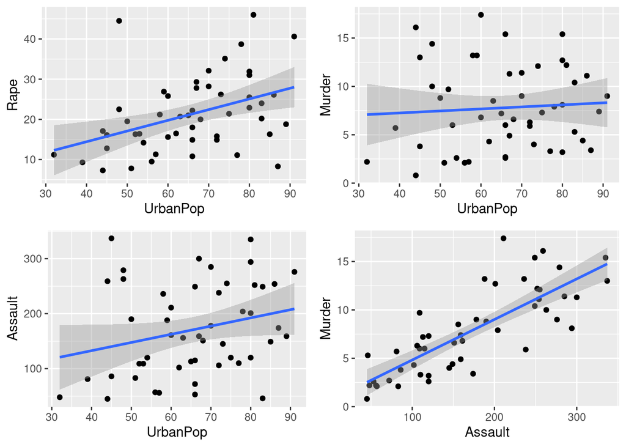

```r
#Exercício3
g6<-ggplot(mydata,aes(x=UrbanPop,y=Rape))
g6<-g6+ geom_point()
g6<-g6+ geom_smooth(method="lm")

g7<-ggplot(mydata,aes(x=UrbanPop,y=Murder))
g7<-g7+ geom_point()
g7<-g7+ geom_smooth(method="lm")

g8<-ggplot(mydata,aes(x=UrbanPop,y=Assault))
g8<-g8+ geom_point()
g8<-g8+ geom_smooth(method="lm")

g9<-ggplot(mydata,aes(x=Assault,y=Murder))
g9<-g9+ geom_point()
g9<-g9+ geom_smooth(method="lm")

grid.arrange(g6,g7,g8,g9, ncol=2)
```

Os gráficos relacionam a porcentagem de população urbana e os crimes, e no último gráfico, a relação entre assaltos e assassinatos. Brevemente, há uma leve relação de proporcionalidade entre a parcela de população vivendo nas cidade com o número de estupros e assaltos, mas não há grande relação com os assassinatos. Já a relação entre assassinatos e assaltos é bem acentuada.

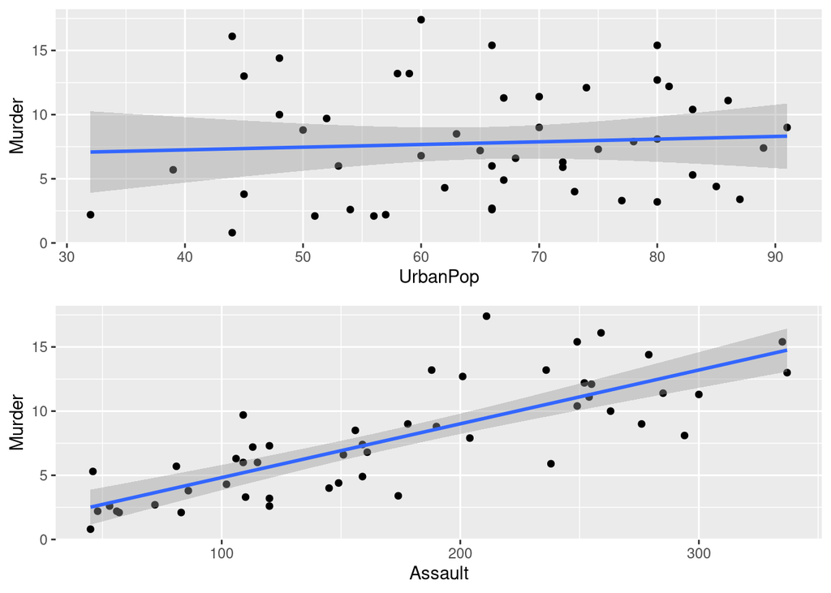

```r
#Exercício4
g10<-ggplot(mydata,aes(x=UrbanPop,y=Murder))
g10<-g10+ geom_point()
g10<-g10+ geom_smooth(method="lm")

g11<-ggplot(mydata,aes(x=Assault,y=Murder))
g11<-g11+ geom_point()
g11<-g11+ geom_smooth(method="lm")

grid.arrange(g10,g11)
```

Não há uma relação aparente entre o número de assassinatos em relação à quantidade de pessoas vivendo em cidades, ao passo que há uma relação íntima entre assassinatos e assaltos.

```r
#Exercício5
data("mpg")
head(mpg)
```

```
## # A tibble: 6 × 11
##   manufacturer model displ  year   cyl trans      drv     cty   hwy fl    class
##   <chr>        <chr> <dbl> <int> <int> <chr>      <chr> <int> <int> <chr> <chr>
## 1 audi         a4      1.8  1999     4 auto(l5)   f        18    29 p     compa…
## 2 audi         a4      1.8  1999     4 manual(m5) f        21    29 p     compa…
## 3 audi         a4      2    2008     4 manual(m6) f        20    31 p     compa…
## 4 audi         a4      2    2008     4 auto(av)   f        21    30 p     compa…
## 5 audi         a4      2.8  1999     6 auto(l5)   f        16    26 p     compa…
## 6 audi         a4      2.8  1999     6 manual(m5) f        18    26 p     compa…
```

```r
tail(mpg)
```

```
## # A tibble: 6 × 11
##   manufacturer model  displ  year   cyl trans      drv     cty   hwy fl    class
##   <chr>        <chr>  <dbl> <int> <int> <chr>      <chr> <int> <int> <chr> <chr>
## 1 volkswagen   passat   1.8  1999     4 auto(l5)   f        18    29 p     mids…
## 2 volkswagen   passat   2    2008     4 auto(s6)   f        19    28 p     mids…
## 3 volkswagen   passat   2    2008     4 manual(m6) f        21    29 p     mids…
## 4 volkswagen   passat   2.8  1999     6 auto(l5)   f        16    26 p     mids…
## 5 volkswagen   passat   2.8  1999     6 manual(m5) f        18    26 p     mids…
## 6 volkswagen   passat   3.6  2008     6 auto(s6)   f        17    26 p     mids…
```

```r
dim(mpg)
```

```
## [1] 234  11
```

```r
summary(mpg)
```

```
##  manufacturer          model               displ            year
##  Length:234         Length:234         Min.   :1.600   Min.   :1999
##  Class :character   Class :character   1st Qu.:2.400   1st Qu.:1999
##  Mode  :character   Mode  :character   Median :3.300   Median :2004
##                                        Mean   :3.472   Mean   :2004
##                                        3rd Qu.:4.600   3rd Qu.:2008
##                                        Max.   :7.000   Max.   :2008
##       cyl           trans               drv                 cty
##  Min.   :4.000   Length:234         Length:234         Min.   : 9.00
##  1st Qu.:4.000   Class :character   Class :character   1st Qu.:14.00
##  Median :6.000   Mode  :character   Mode  :character   Median :17.00
##  Mean   :5.889                                         Mean   :16.86
##  3rd Qu.:8.000                                         3rd Qu.:19.00
##  Max.   :8.000                                         Max.   :35.00
##       hwy             fl               class
##  Min.   :12.00   Length:234         Length:234
##  1st Qu.:18.00   Class :character   Class :character
##  Median :24.00   Mode  :character   Mode  :character
##  Mean   :23.44
##  3rd Qu.:27.00
##  Max.   :44.00
```

```r
names(mpg)
```

```
##  [1] "manufacturer" "model"        "displ"        "year"         "cyl"
##  [6] "trans"        "drv"          "cty"          "hwy"          "fl"
## [11] "class"
```

```r
row(mpg)
```

[output not shown]

[output cut: 220 more lines]

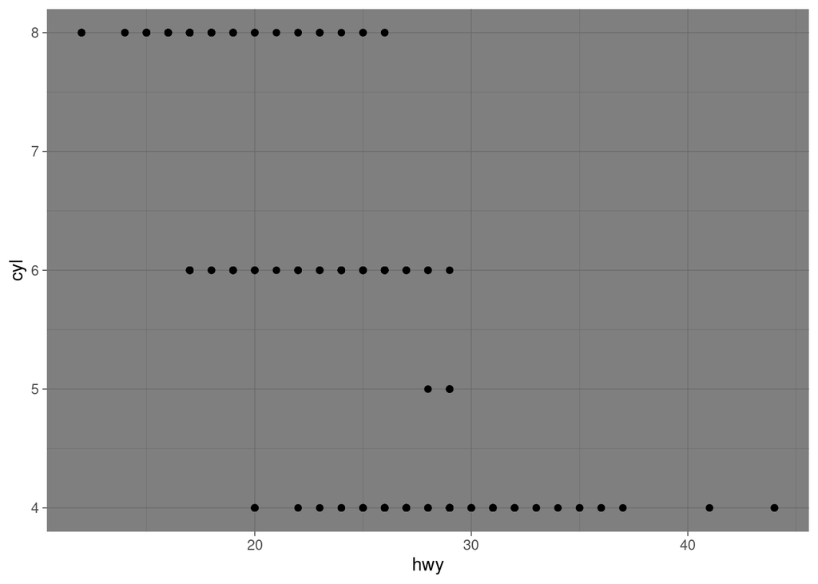

```r
#Exercício6
g12<-ggplot(data=mpg) + geom_point(aes(x=hwy,y=cyl))
g12<-g12+ theme_dark()
g12
```

Os cilindros (em y) apresentam um valor discreto, e são componentes fundamentais do carro. Dentro deles, entra a mistura rica que é explodida. Dentro de cada categoria de quantidade de cilindros, há uma variabilidade devido ao projeto dos carros que possibilita valores distintos de rendimento de combustível. Contudo, quanto maior a quantidade de cilindros, maior tende a ser a quantidade de combustível usado a cada ciclo do carro. Por isso, quanto maior o número de cilindros, os pontos tendem a se agrupar em regiões mais próximas de baixos rendimentos de combustível.

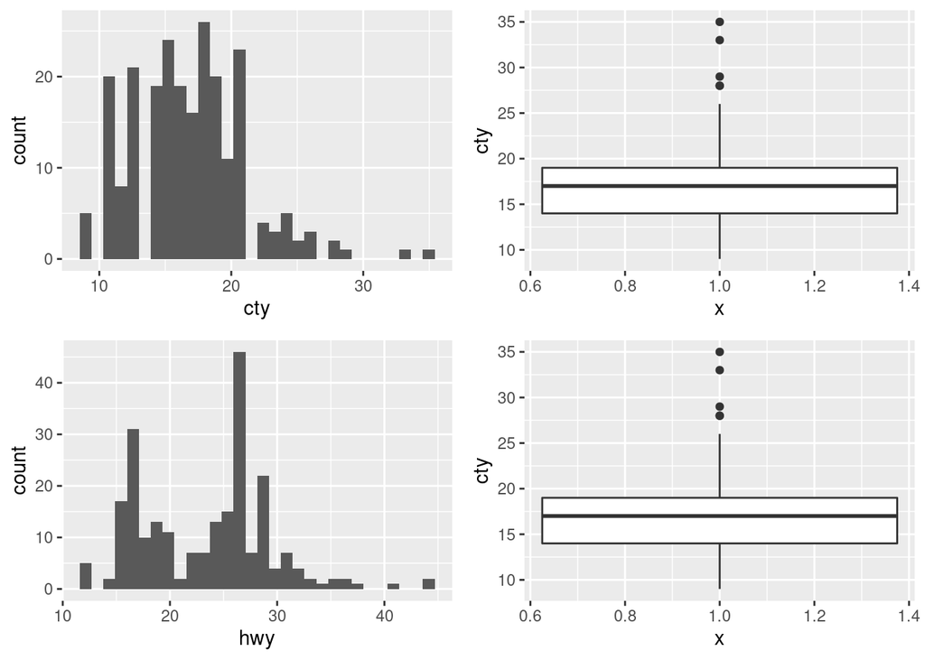

```r
#Exercício7
g13<- ggplot(mpg)
g13<-g13+ geom_histogram(mapping=aes(cty))

g14<- ggplot(mpg)
g14<-g14+ geom_histogram(mapping=aes(hwy))

g15<- ggplot(mpg) + geom_boxplot(mapping = aes(x = 1, y = cty))

g16<- ggplot(mpg) + geom_boxplot(mapping = aes(x = 1, y = hwy))

grid.arrange(g13,g15,g14,g15,ncol=2)
```

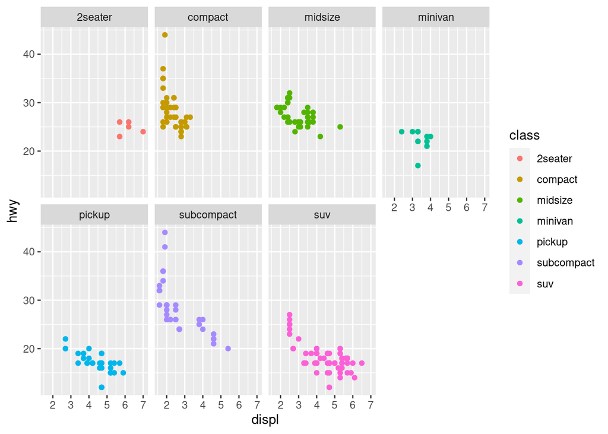

```r
#Exercício8
#parte1
g13<- ggplot(mpg)
g13<-g13+ geom_point(aes(x=displ,y=hwy, color=class))
g13<-g13+facet_wrap(~class,nrow=2)
g13
```

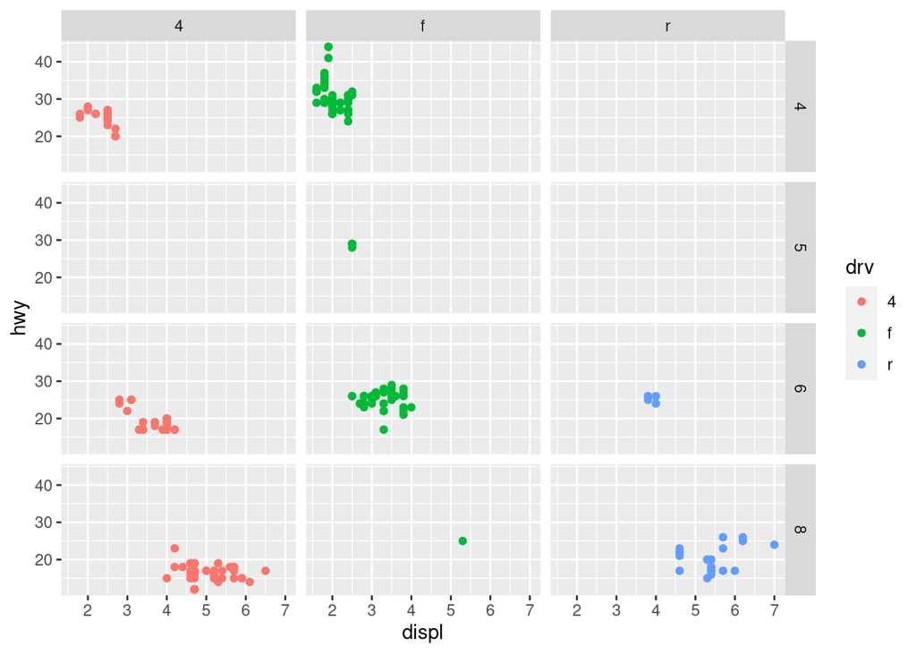

```r
#parte2
g14<- ggplot(mpg)
g14<-g14+ geom_point(aes(x=displ,y=hwy, color=drv))
g14<-g14+facet_grid(cyl~drv)
g14
```

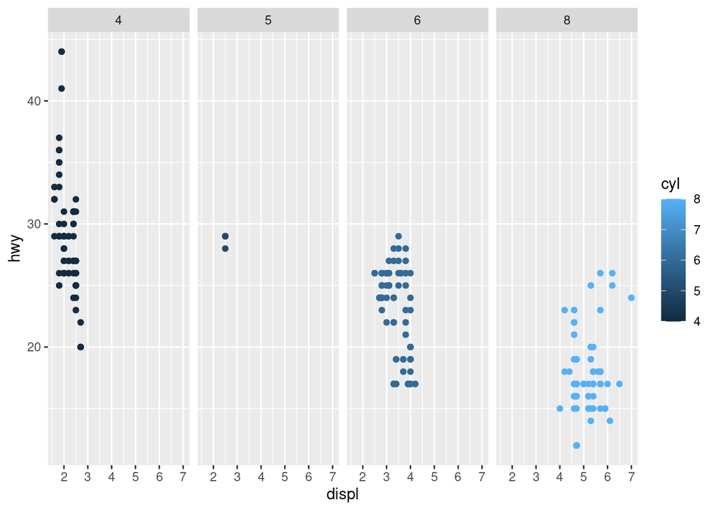

```r
#parte3
g15<- ggplot(mpg)
g15<-g15+ geom_point(aes(x=displ,y=hwy, color=cyl))
g15<-g15+facet_grid(.~cyl)
g15
```

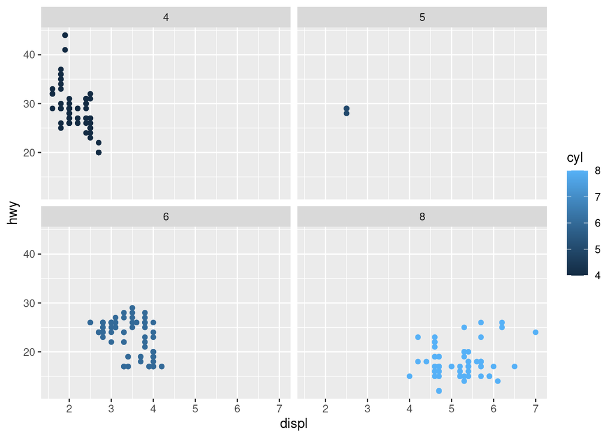

```r
g16<- ggplot(mpg)
g16<-g16+ geom_point(aes(x=displ,y=hwy, color=cyl))
g16<-g16+facet_wrap(~cyl)
g16
```

Ao colocarmos facet_grid(.~cyl) e color=cyl, o resultado é semelhante se usássemos facet_wrap(~cyl), mas o plot considera que é preciso plotar todos os gráficos em uma linha somente, ao passo em que o recurso facet_wrap() organiza de forma mais proporcional os gráficos, em duas linhas e duas colunas.

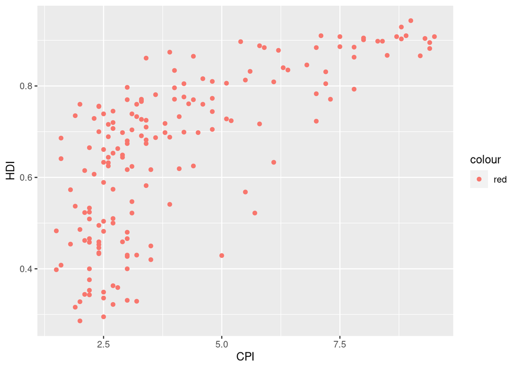

```r
#Exercício9
library(readxl)
dados=read_excel("~/Downloads/homework2.xlsx")
dados$Region=as.factor(dados$Region)
dados$CPI=as.numeric(dados$CPI)
dados$HDI=as.numeric(dados$HDI)
#a
a1<- ggplot(dados,aes(x=CPI,y=HDI))
a1<-a1+ geom_point(aes(color="red"))
a1
```

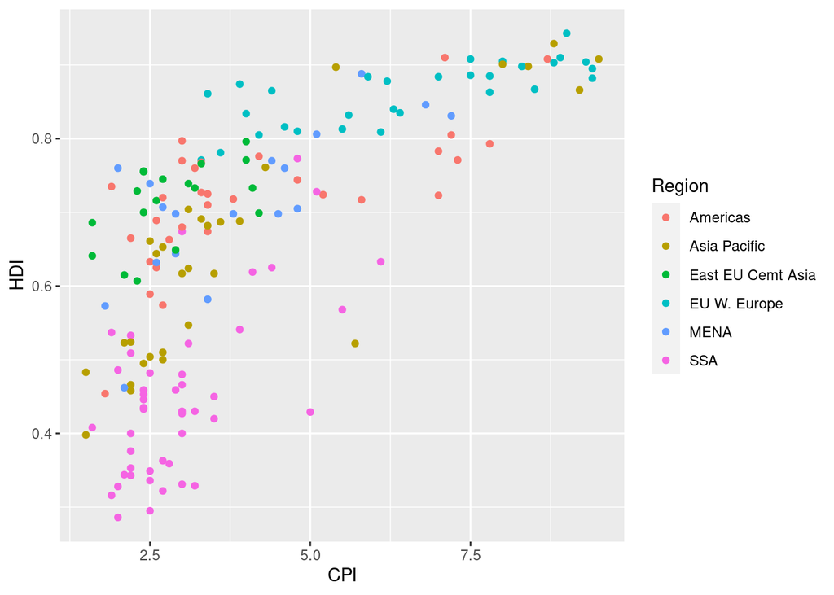

```r
#b
a2 <- ggplot(dados,aes(x=CPI,y=HDI))
a2<-a2+ geom_point(aes(color=Region))
a2
```

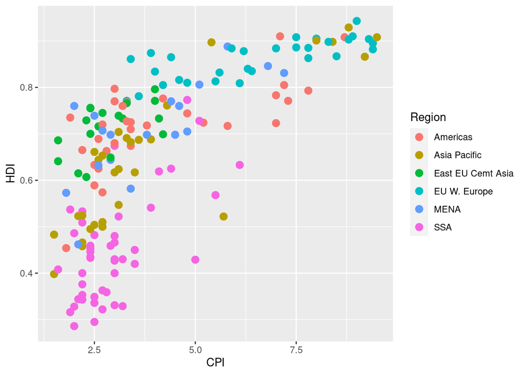

```r
#c
a3 <- ggplot(dados,aes(x=CPI,y=HDI))
a3<-a3+ geom_point(aes(color=Region),size=3)
a3
```

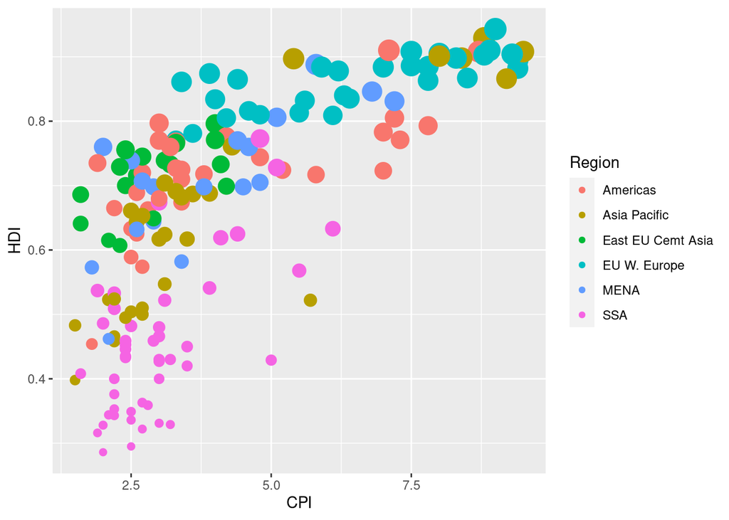

```r
#d
a4 <- ggplot(dados,aes(x=CPI,y=HDI))
a4<-a4+ geom_point(aes(color=Region),size=7*dados$HDI)
a4
```

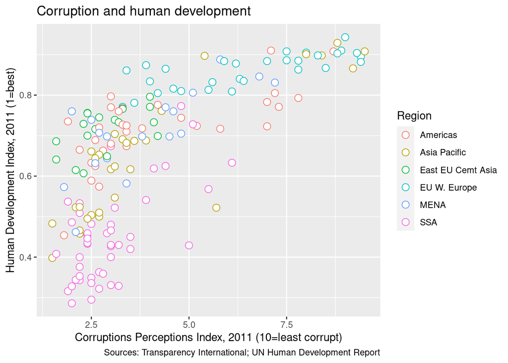

```r
#e
a5 <- ggplot(dados,aes(x=CPI,y=HDI))
a5<-a5+ geom_point(shape=21,aes(color=Region),fill= "white" ,size=3)
a5<-a5+ labs(title="Corruption and human development",caption="Sources: Transparency International; UN Human Development Report",x="Corruptions Perceptions Index, 2011 (10=least corrupt)",y="Human Development Index, 2011 (1=best)")
a5
```

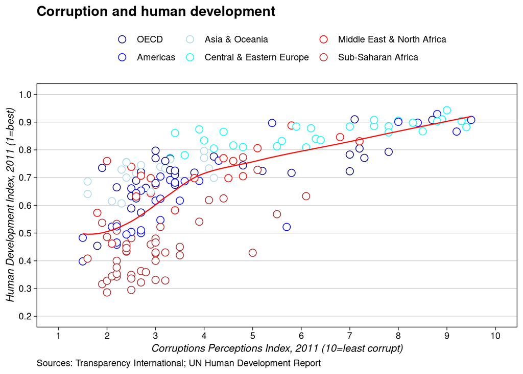

```r
#f
aaa <- ggplot(dados,aes(x=CPI,y=HDI))
aaa<-aaa+ geom_point(shape=21,aes(color=Region),fill= "white" ,size=3)
aaa<- aaa+geom_smooth(se=FALSE, formula= "y~sqrt(x)", color= "red",size=0.5)
aaa<-aaa+scale_color_manual("", values = c("dark blue","blue", "light blue","cyan","red","brown"),
labels = c("OECD","Americas", "Asia & Oceania","Central & Eastern Europe","Middle East & North Africa","Sub-Saharan Africa"))
aaa<-aaa+ labs(title="Corruption and human development",caption="Sources: Transparency International; UN Human Development Report",x="Corruptions Perceptions Index, 2011 (10=least corrupt)",y="Human Development Index, 2011 (1=best)")
aaa<- aaa+theme_linedraw()
aaa<-aaa+theme(legend.position ="top",plot.title =element_text(face="bold"),axis.title.x = element_text(face = "italic", size=10),axis.title.y = element_text(face="italic", size=10),plot.caption=element_text(hjust=0))
aaa<-aaa+ scale_y_continuous(limits=c(0.2,1),breaks=seq(0,10,0.1),minor_breaks = NULL)
aaa<- aaa+ scale_x_continuous(limits=c(1,10),breaks=seq(1,10,1), minor_breaks = NULL)
aaa<- aaa+ theme(panel.grid.major.x = element_blank())
aaa
```